# wine

```python
import pandas as pd
df=pd.read_csv("wine_quality_dataset.csv")
```

```python
df.head()
```

|  | fixed acidity | volatile acidity | citric acid | residual sugar | chlorides | free sulfur dioxide | total sulfur dioxide | density | pH | sulphates | alcohol | quality | Id |
| --- | --- | --- | --- | --- | --- | --- | --- | --- | --- | --- | --- | --- | --- |
| 0 | 7.4 | 0.70 | 0.00 | 1.9 | 0.076 | 11.0 | 34.0 | 0.9978 | 3.51 | 0.56 | 9.4 | 5 | 0 |
| 1 | 7.8 | 0.88 | 0.00 | 2.6 | 0.098 | 25.0 | 67.0 | 0.9968 | 3.20 | 0.68 | 9.8 | 5 | 1 |
| 2 | 7.8 | 0.76 | 0.04 | 2.3 | 0.092 | 15.0 | 54.0 | 0.9970 | 3.26 | 0.65 | 9.8 | 5 | 2 |
| 3 | 11.2 | 0.28 | 0.56 | 1.9 | 0.075 | 17.0 | 60.0 | 0.9980 | 3.16 | 0.58 | 9.8 | 6 | 3 |
| 4 | 7.4 | 0.70 | 0.00 | 1.9 | 0.076 | 11.0 | 34.0 | 0.9978 | 3.51 | 0.56 | 9.4 | 5 | 4 |

```python
# Check the number of rows and columns
print("Dataset shape:", df.shape)

# Display column names
print("\nColumn names:")
print(df.columns.tolist())

# Display data types and non-null values
print("\nDataset information:")
df.info()
```

```
Dataset shape: (1143, 13)

Column names:
['fixed acidity', 'volatile acidity', 'citric acid', 'residual sugar', 'chlorides', 'free sulfur dioxide', 'total sulfur dioxide', 'density', 'pH', 'sulphates', 'alcohol', 'quality', 'Id']

Dataset information:
<class 'pandas.core.frame.DataFrame'>
RangeIndex: 1143 entries, 0 to 1142
Data columns (total 13 columns):
 #   Column                Non-Null Count  Dtype
---  ------                --------------  -----
 0   fixed acidity         1143 non-null   float64
 1   volatile acidity      1143 non-null   float64
 2   citric acid           1143 non-null   float64
 3   residual sugar        1143 non-null   float64
 4   chlorides             1143 non-null   float64
 5   free sulfur dioxide   1143 non-null   float64
 6   total sulfur dioxide  1143 non-null   float64
 7   density               1143 non-null   float64
 8   pH                    1143 non-null   float64
 9   sulphates             1143 non-null   float64
 10  alcohol               1143 non-null   float64
 11  quality               1143 non-null   int64
 12  Id                    1143 non-null   int64
dtypes: float64(11), int64(2)
memory usage: 116.2 KB
```

```python
# Count the number of wines for each quality score
quality_counts = df["quality"].value_counts().sort_index()

print("Quality score distribution:")
print(quality_counts)
```

```
Quality score distribution:
quality
3      6
4     33
5    483
6    462
7    143
8     16
Name: count, dtype: int64
```

```python
# Calculate percentage distribution
quality_percentage = df["quality"].value_counts(normalize=True).sort_index() * 100

print("Quality score percentage distribution:")
print(quality_percentage.round(2))
```

```
Quality score percentage distribution:
quality
3     0.52
4     2.89
5    42.26
6    40.42
7    12.51
8     1.40
Name: proportion, dtype: float64
```

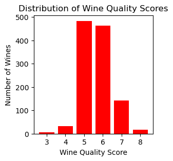

```python
import matplotlib.pyplot as plt

quality_counts = df["quality"].value_counts().sort_index()

plt.figure(figsize=(3, 3))

plt.bar(
    quality_counts.index,
    quality_counts.values,
    color="red"
)

plt.xlabel("Wine Quality Score")
plt.ylabel("Number of Wines")
plt.title("Distribution of Wine Quality Scores")
plt.xticks(quality_counts.index)

plt.show()
```

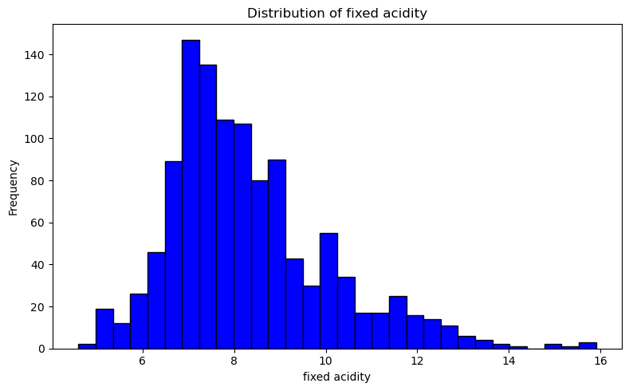

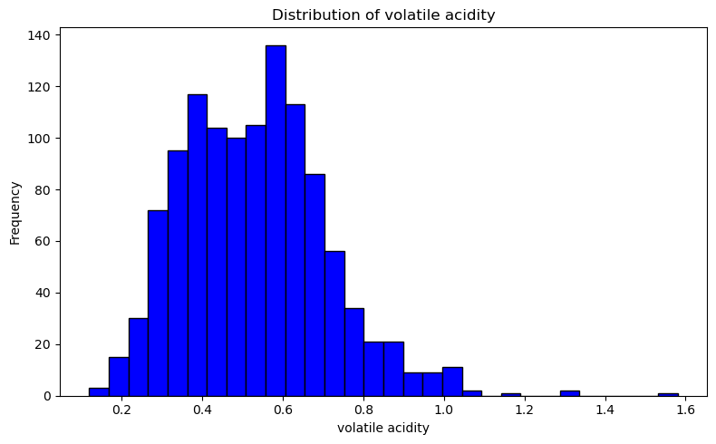

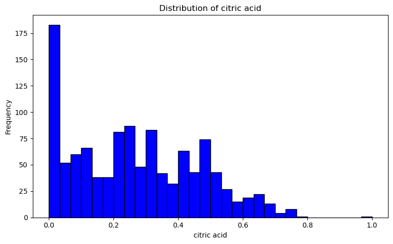

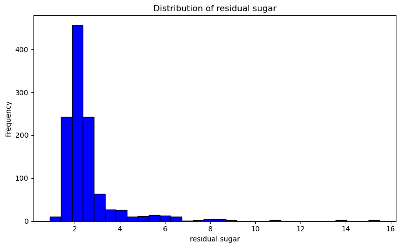

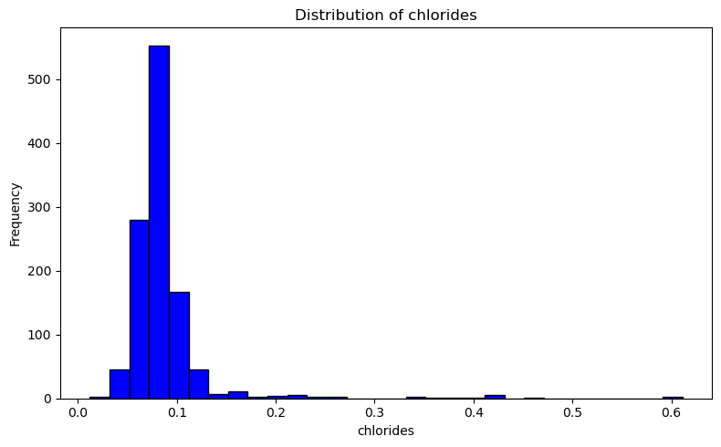

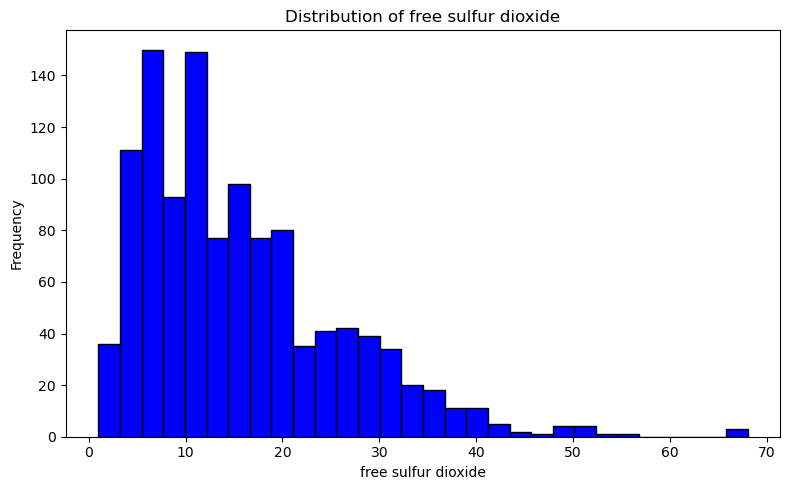

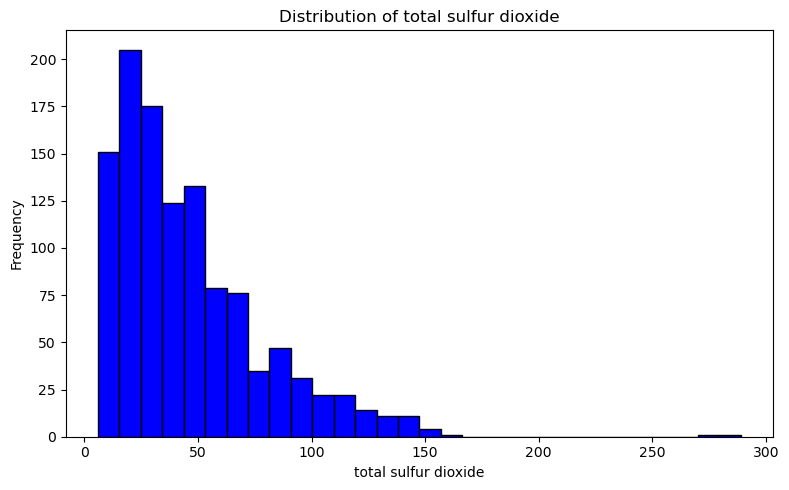

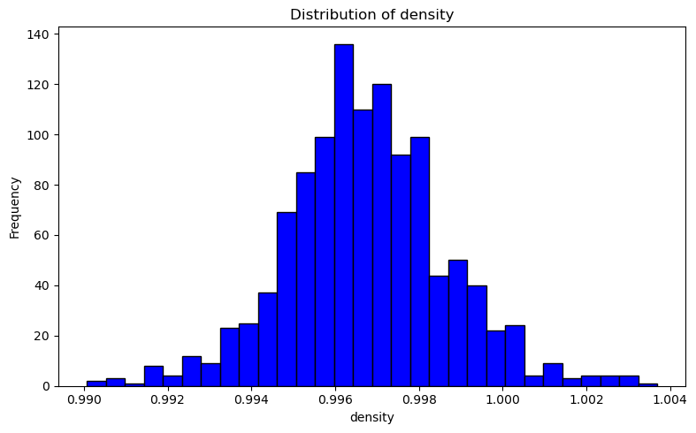

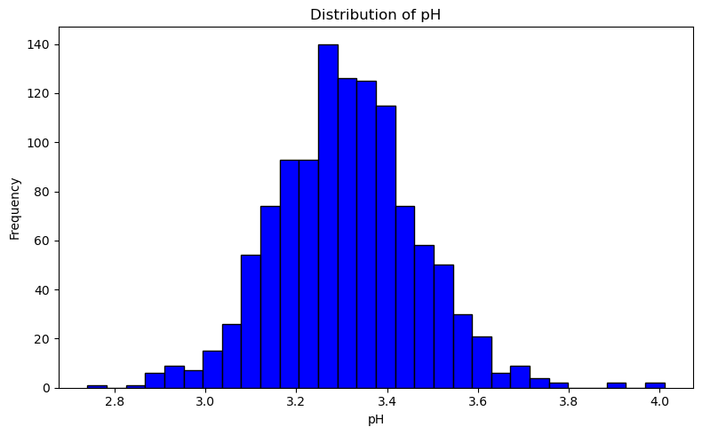

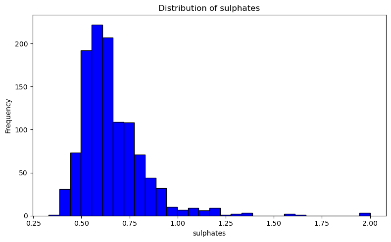

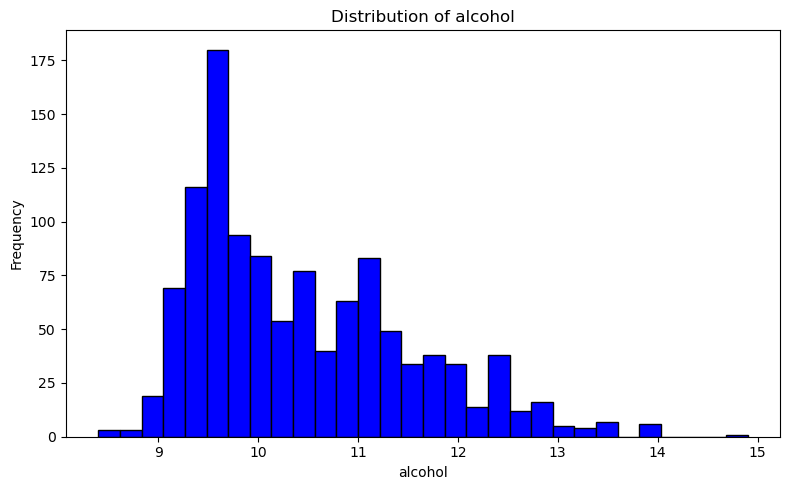

```python
import matplotlib.pyplot as plt

# Select the chemical features
chemical_features = [
    "fixed acidity",
    "volatile acidity",
    "citric acid",
    "residual sugar",
    "chlorides",
    "free sulfur dioxide",
    "total sulfur dioxide",
    "density",
    "pH",
    "sulphates",
    "alcohol"
]

# Create a distribution plot for each chemical feature
for column in chemical_features:
    plt.figure(figsize=(8, 5))

    plt.hist(df[column].dropna(), bins=30, color="blue", edgecolor="black")

    plt.title(f"Distribution of {column}")
    plt.xlabel(column)
    plt.ylabel("Frequency")

    plt.tight_layout()
    plt.show()
```

### EDA: distribution plots for all chemical features; correlation heatmap

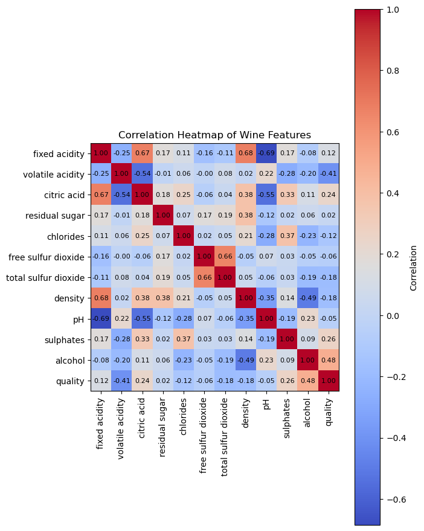

```python
import matplotlib.pyplot as plt
import numpy as np

# Select numerical columns
correlation = df[chemical_features + ["quality"]].corr()

# Create the heatmap
plt.figure(figsize=(7, 9))

plt.imshow(correlation, cmap="coolwarm", interpolation="nearest")

# Add colour bar
plt.colorbar(label="Correlation")

# Add labels
plt.xticks(
    range(len(correlation.columns)),
    correlation.columns,
    rotation=90
)

plt.yticks(
    range(len(correlation.columns)),
    correlation.columns
)

# Add correlation values inside the heatmap
for i in range(len(correlation.columns)):
    for j in range(len(correlation.columns)):
        plt.text(
            j, i,
            f"{correlation.iloc[i, j]:.2f}",
            ha="center",
            va="center",
            fontsize=8
        )

plt.title("Correlation Heatmap of Wine Features")
plt.tight_layout()
plt.show()
```

## Exploratory Data Analysis (EDA)

### Distribution of Chemical Features

Histograms were used to examine the distribution of the chemical features in the Wine Quality dataset. These plots help identify the spread, concentration, and possible skewness of each variable.

### Correlation Heatmap

A correlation heatmap was created to examine the relationships between the chemical features and wine quality. Correlation values range from -1 to +1. Values close to +1 indicate a strong positive relationship, while values close to -1 indicate a strong negative relationship. Values close to 0 indicate a weak or no linear relationship.

### Discuss class imbalance: are certain quality scores underrepresented? How does this affect modelling?

```python
# Count each quality score
quality_counts = df["quality"].value_counts().sort_index()

print("Number of wines in each quality class:")
print(quality_counts)
```

```
Number of wines in each quality class:
quality
3      6
4     33
5    483
6    462
7    143
8     16
Name: count, dtype: int64
```

```python
# Calculate percentage distribution
quality_percentage = (
    df["quality"].value_counts(normalize=True).sort_index() * 100
)

print("Percentage of wines in each quality class:")
print(quality_percentage.round(2))
```

```
Percentage of wines in each quality class:
quality
3     0.52
4     2.89
5    42.26
6    40.42
7    12.51
8     1.40
Name: proportion, dtype: float64
```

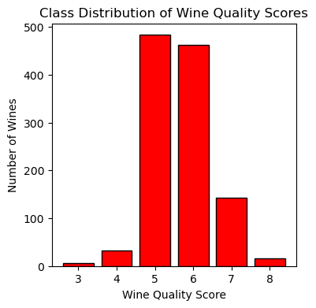

```python
import matplotlib.pyplot as plt

plt.figure(figsize=(4, 4))

plt.bar(
    quality_counts.index,
    quality_counts.values,
    color="red",
    edgecolor="black"
)

plt.xlabel("Wine Quality Score")
plt.ylabel("Number of Wines")
plt.title("Class Distribution of Wine Quality Scores")
plt.xticks(quality_counts.index)

plt.show()
```

```python
most_common = quality_counts.idxmax()
least_common = quality_counts.idxmin()

print(f"Most represented quality score: {most_common}")
print(f"Number of wines: {quality_counts.max()}")

print(f"\nLeast represented quality score: {least_common}")
print(f"Number of wines: {quality_counts.min()}")
```

```
Most represented quality score: 5
Number of wines: 483

Least represented quality score: 3
Number of wines: 6
```

## Class Imbalance

The distribution of wine quality scores was examined to determine whether all quality classes are equally represented. The results show that some quality scores have considerably more observations than others.

This indicates class imbalance in the dataset. In particular, the extreme quality scores tend to have fewer observations compared with the more common middle quality scores.

Class imbalance can affect machine learning models because the model may become biased towards the majority classes. As a result, the model may perform well on common quality scores but perform poorly when predicting underrepresented scores.

Therefore, accuracy alone may not be sufficient for evaluating the model. Metrics such as precision, recall, F1-score, and a confusion matrix should also be considered. Techniques such as class weighting, oversampling, or undersampling may also be considered if the imbalance significantly affects model performance.

### Feature engineering: consider binning quality scores into binary (good/bad) or 3-class (low/medium/high) groups and justify the decision

```python
# Check the unique quality scores
print(sorted(df["quality"].unique()))
```

```
[3, 4, 5, 6, 7, 8]
```

```python
# Create a new quality group
def quality_group(score):
    if score <= 4:
        return "Low"
    elif score <= 6:
        return "Medium"
    else:
        return "High"

df["quality_group"] = df["quality"].apply(quality_group)

# Display the first few rows
df[["quality", "quality_group"]].head(10)
```

|  | quality | quality_group |
| --- | --- | --- |
| 0 | 5 | Medium |
| 1 | 5 | Medium |
| 2 | 5 | Medium |
| 3 | 6 | Medium |
| 4 | 5 | Medium |
| 5 | 5 | Medium |
| 6 | 5 | Medium |
| 7 | 7 | High |
| 8 | 7 | High |
| 9 | 5 | Medium |

```python
# Count each new quality group
group_counts = df["quality_group"].value_counts()

print(group_counts)
```

```
quality_group
Medium    945
High      159
Low        39
Name: count, dtype: int64
```

## Feature Engineering: Wine Quality Groups

The original `quality` variable contains several individual quality scores. To make the target variable easier to use for classification modelling, the scores were grouped into three categories:

- **Low:** quality scores 3–4
- **Medium:** quality scores 5–6
- **High:** quality scores 7–8

A three-class approach was selected instead of a binary good/bad classification because it preserves more information from the original quality scores. It also allows the model to distinguish between low-, medium-, and high-quality wines.

This grouping can make the classification problem more practical and easier to interpret. However, the class distribution should be checked because the Low and High groups may contain fewer observations than the Medium group. If the imbalance is substantial, techniques such as class weighting or resampling may be considered during modelling.

### Train/test split with stratification to preserve class ratios

```python
# Import the required library
from sklearn.model_selection import train_test_split

# Create the 3 quality groups
def quality_group(score):
    if score <= 4:
        return "Low"
    elif score <= 6:
        return "Medium"
    else:
        return "High"

df["quality_group"] = df["quality"].apply(quality_group)

# Select the chemical features
X = df[[
    "fixed acidity",
    "volatile acidity",
    "citric acid",
    "residual sugar",
    "chlorides",
    "free sulfur dioxide",
    "total sulfur dioxide",
    "density",
    "pH",
    "sulphates",
    "alcohol"
]]

# Select the target
y = df["quality_group"]

# Split the data into 80% training and 20% testing
X_train, X_test, y_train, y_test = train_test_split(
    X,
    y,
    test_size=0.20,
    random_state=42,
    stratify=y
)

# Display the results
print("Training data:", X_train.shape)
print("Testing data:", X_test.shape)

print("\nTraining class distribution:")
print(y_train.value_counts())

print("\nTesting class distribution:")
print(y_test.value_counts())
```

```
Training data: (914, 11)
Testing data: (229, 11)

Training class distribution:
quality_group
Medium    756
High      127
Low        31
Name: count, dtype: int64

Testing class distribution:
quality_group
Medium    189
High       32
Low         8
Name: count, dtype: int64
```

## Train/Test Split with Stratification

The dataset was divided into two parts: **80% training data** and **20% testing data**.

The `quality_group` variable was used as the target variable, with the wine quality scores grouped into three categories: **Low, Medium, and High**.

Stratified sampling was applied to ensure that the proportion of Low, Medium, and High quality wines remained approximately the same in both the training and testing datasets.

This approach is important because the Wine Quality dataset has an uneven distribution of quality classes. Maintaining similar class proportions helps the machine learning model learn from representative data and provides a more reliable evaluation of its performance.

A `random_state` of 42 was used to ensure that the same train/test split can be reproduced whenever the code is run.

### Train 3 classifiers: Random Forest, Stochastic Gradient Descent (SGD), and Support Vector Classifier (SVC)

```python
# ============================================
# WINE QUALITY - TRAIN 3 CLASSIFIERS
# ============================================

import pandas as pd

from sklearn.model_selection import train_test_split
from sklearn.preprocessing import StandardScaler
from sklearn.ensemble import RandomForestClassifier
from sklearn.linear_model import SGDClassifier
from sklearn.svm import SVC


# 2. CREATE QUALITY GROUPS
def create_quality_group(score):
    if score <= 4:
        return "Low"
    elif score <= 6:
        return "Medium"
    else:
        return "High"


df["quality_group"] = df["quality"].apply(create_quality_group)


# 3. SELECT FEATURES
features = [
    "fixed acidity",
    "volatile acidity",
    "citric acid",
    "residual sugar",
    "chlorides",
    "free sulfur dioxide",
    "total sulfur dioxide",
    "density",
    "pH",
    "sulphates",
    "alcohol"
]

X = df[features]
y = df["quality_group"]


# 4. SPLIT DATA
X_train, X_test, y_train, y_test = train_test_split(
    X,
    y,
    test_size=0.20,
    random_state=42,
    stratify=y
)


# 5. SCALE FEATURES FOR SGD AND SVC
scaler = StandardScaler()

X_train_scaled = scaler.fit_transform(X_train)
X_test_scaled = scaler.transform(X_test)


# 6. RANDOM FOREST
random_forest = RandomForestClassifier(
    n_estimators=100,
    random_state=42
)

random_forest.fit(X_train, y_train)


# 7. SGD CLASSIFIER
sgd = SGDClassifier(
    max_iter=1000,
    random_state=42
)

sgd.fit(X_train_scaled, y_train)


# 8. SUPPORT VECTOR CLASSIFIER
svc = SVC(
    random_state=42
)

svc.fit(X_train_scaled, y_train)


# 9. MAKE PREDICTIONS
rf_pred = random_forest.predict(X_test)

sgd_pred = sgd.predict(X_test_scaled)

svc_pred = svc.predict(X_test_scaled)


# 10. CONFIRM EVERYTHING WORKED
print("Models trained successfully!")
print("--------------------------------")
print("Random Forest:        OK")
print("SGD Classifier:       OK")
print("Support Vector (SVC): OK")

print("\nTraining rows:", len(X_train))
print("Testing rows:", len(X_test))
```

```
Models trained successfully!
--------------------------------
Random Forest:        OK
SGD Classifier:       OK
Support Vector (SVC): OK

Training rows: 914
Testing rows: 229
```

## Training Classification Models

Three machine learning classification models were trained to predict wine quality groups: Random Forest, Stochastic Gradient Descent (SGD), and Support Vector Classifier (SVC).

The wine quality scores were grouped into three categories: Low, Medium, and High. The dataset was divided into 80% training data and 20% testing data using stratified sampling to maintain the class proportions.

Standardisation was applied to the features used by SGD and SVC because these algorithms are sensitive to differences in feature scales. Random Forest was trained using the original feature values because scaling is not required for tree-based models.

The three models were trained using the same training data and will be compared using their performance on the test data.

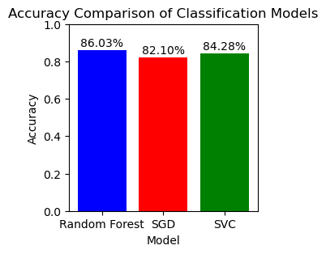

```python
import matplotlib.pyplot as plt
from sklearn.metrics import accuracy_score

# Calculate accuracy
rf_accuracy = accuracy_score(y_test, rf_pred)
sgd_accuracy = accuracy_score(y_test, sgd_pred)
svc_accuracy = accuracy_score(y_test, svc_pred)

# Model names and accuracy values
models = ["Random Forest", "SGD", "SVC"]
accuracies = [rf_accuracy, sgd_accuracy, svc_accuracy]

# Create bar chart
plt.figure(figsize=(3, 3))
bars = plt.bar(models, accuracies, color=["blue", "red", "green"])

plt.title("Accuracy Comparison of Classification Models")
plt.xlabel("Model")
plt.ylabel("Accuracy")
plt.ylim(0, 1)

# Add accuracy values on top of bars
for bar, value in zip(bars, accuracies):
    plt.text(
        bar.get_x() + bar.get_width() / 2,
        value + 0.02,
        f"{value:.2%}",
        ha="center"
    )

plt.show()
```

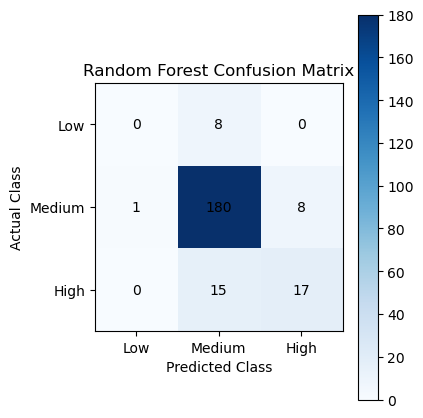

```python
from sklearn.metrics import confusion_matrix

rf_cm = confusion_matrix(
    y_test,
    rf_pred,
    labels=["Low", "Medium", "High"]
)

plt.figure(figsize=(4, 5))
plt.imshow(rf_cm, cmap="Blues")

plt.title("Random Forest Confusion Matrix")
plt.xlabel("Predicted Class")
plt.ylabel("Actual Class")

plt.xticks(range(3), ["Low", "Medium", "High"])
plt.yticks(range(3), ["Low", "Medium", "High"])

for i in range(3):
    for j in range(3):
        plt.text(j, i, rf_cm[i, j], ha="center", va="center")

plt.colorbar()
plt.show()
```

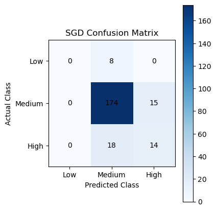

```python
sgd_cm = confusion_matrix(
    y_test,
    sgd_pred,
    labels=["Low", "Medium", "High"]
)

plt.figure(figsize=(4, 5))
plt.imshow(sgd_cm, cmap="Blues")

plt.title("SGD Confusion Matrix")
plt.xlabel("Predicted Class")
plt.ylabel("Actual Class")

plt.xticks(range(3), ["Low", "Medium", "High"])
plt.yticks(range(3), ["Low", "Medium", "High"])

for i in range(3):
    for j in range(3):
        plt.text(j, i, sgd_cm[i, j], ha="center", va="center")

plt.colorbar()
plt.show()
```

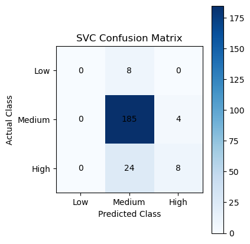

```python
svc_cm = confusion_matrix(
    y_test,
    svc_pred,
    labels=["Low", "Medium", "High"]
)

plt.figure(figsize=(4, 5))
plt.imshow(svc_cm, cmap="Blues")

plt.title("SVC Confusion Matrix")
plt.xlabel("Predicted Class")
plt.ylabel("Actual Class")

plt.xticks(range(3), ["Low", "Medium", "High"])
plt.yticks(range(3), ["Low", "Medium", "High"])

for i in range(3):
    for j in range(3):
        plt.text(j, i, svc_cm[i, j], ha="center", va="center")

plt.colorbar()
plt.show()
```

## Model Evaluation and Visualisation

The three classification models — **Random Forest, Stochastic Gradient Descent (SGD), and Support Vector Classifier (SVC)** — were evaluated using their predictions on the test dataset.

A **bar chart** was used to compare the accuracy of the three models. Accuracy represents the proportion of wine quality predictions that were correctly classified.

**Confusion matrices** were also created for each model to provide a more detailed view of the predictions. The matrices show the number of wines that were correctly and incorrectly classified as **Low, Medium, or High** quality.

The values along the diagonal of each confusion matrix represent correct predictions, while values outside the diagonal represent incorrect predictions.

These visualisations make it easier to compare the performance of the three classifiers and identify which quality classes are more difficult for each model to predict.

### Feature importance chart for the Random Forest model

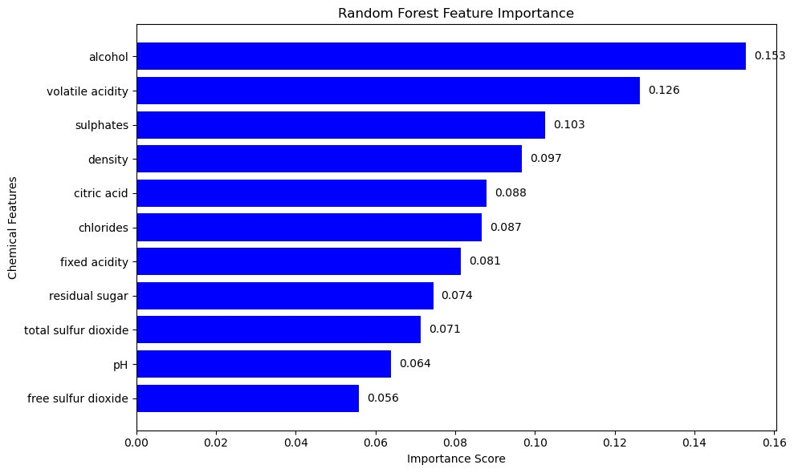

```python
import matplotlib.pyplot as plt

importance = random_forest.feature_importances_
features = X_train.columns

sorted_indices = importance.argsort()

plt.figure(figsize=(10, 6))

bars = plt.barh(
    features[sorted_indices],
    importance[sorted_indices],
    color="blue"
)

plt.xlabel("Importance Score")
plt.ylabel("Chemical Features")
plt.title("Random Forest Feature Importance")

for bar in bars:
    value = bar.get_width()
    plt.text(
        value + 0.002,
        bar.get_y() + bar.get_height() / 2,
        f"{value:.3f}",
        va="center"
    )

plt.tight_layout()
plt.show()
```

## Random Forest Feature Importance

A feature importance chart was created to identify which chemical properties contribute most to predicting wine quality. The Random Forest model assigns an importance score to each feature based on its contribution to the model's predictions.

Higher importance scores indicate that a feature has a greater influence on the model's classification of wine quality, while lower scores indicate less influence. This helps identify the chemical properties that are most useful for predicting whether a wine is classified as Low, Medium, or High quality.

### Comparison table: summarise the performance of all 3 models side-by-side

```python
import pandas as pd
from sklearn.metrics import accuracy_score, precision_score, recall_score, f1_score

# -----------------------------------
# 1. MAKE PREDICTIONS
# -----------------------------------

rf_pred = random_forest.predict(X_test)

sgd_pred = sgd.predict(X_test_scaled)

svc_pred = svc.predict(X_test_scaled)


# -----------------------------------
# 2. CALCULATE MODEL PERFORMANCE
# -----------------------------------

models = ["Random Forest", "SGD", "SVC"]

accuracy = [
    accuracy_score(y_test, rf_pred),
    accuracy_score(y_test, sgd_pred),
    accuracy_score(y_test, svc_pred)
]

precision = [
    precision_score(y_test, rf_pred, average="weighted", zero_division=0),
    precision_score(y_test, sgd_pred, average="weighted", zero_division=0),
    precision_score(y_test, svc_pred, average="weighted", zero_division=0)
]

recall = [
    recall_score(y_test, rf_pred, average="weighted", zero_division=0),
    recall_score(y_test, sgd_pred, average="weighted", zero_division=0),
    recall_score(y_test, svc_pred, average="weighted", zero_division=0)
]

f1 = [
    f1_score(y_test, rf_pred, average="weighted", zero_division=0),
    f1_score(y_test, sgd_pred, average="weighted", zero_division=0),
    f1_score(y_test, svc_pred, average="weighted", zero_division=0)
]


# -----------------------------------
# 3. CREATE COMPARISON TABLE
# -----------------------------------

comparison_table = pd.DataFrame({
    "Model": models,
    "Accuracy": accuracy,
    "Precision": precision,
    "Recall": recall,
    "F1-Score": f1
})


# -----------------------------------
# 4. ROUND THE RESULTS
# -----------------------------------

comparison_table["Accuracy"] = comparison_table["Accuracy"].round(3)
comparison_table["Precision"] = comparison_table["Precision"].round(3)
comparison_table["Recall"] = comparison_table["Recall"].round(3)
comparison_table["F1-Score"] = comparison_table["F1-Score"].round(3)


# -----------------------------------
# 5. DISPLAY THE TABLE
# -----------------------------------

comparison_table
```

|  | Model | Accuracy | Precision | Recall | F1-Score |
| --- | --- | --- | --- | --- | --- |
| 0 | Random Forest | 0.860 | 0.827 | 0.860 | 0.841 |
| 1 | SGD | 0.821 | 0.785 | 0.821 | 0.802 |
| 2 | SVC | 0.843 | 0.797 | 0.843 | 0.803 |

## Comparison of Model Performance

The performance of the three classification models was compared using accuracy, precision, recall, and F1-score.

Random Forest, SGD, and SVC were evaluated using the same test dataset. This provides a fair comparison of their ability to classify wines into Low, Medium, and High quality groups.

The model with the strongest overall combination of accuracy, precision, recall, and F1-score will be considered the best-performing model. Since the dataset has class imbalance, F1-score, precision, and recall are considered alongside accuracy when selecting the final model.

### Conclusion: which model is most suitable for deployment and why?

```python
# Find the model with the highest F1-score

best_model = comparison_table.loc[
    comparison_table["F1-Score"].idxmax()
]

print("Recommended model for deployment:")
print(best_model["Model"])

print("\nF1-Score:",best_model["F1-Score"])
print("Accuracy:",best_model["Accuracy"])
print("Precision:",best_model["Precision"])
print("Recall:",best_model["Recall"])
```

```
Recommended model for deployment:
Random Forest

F1-Score: 0.841
Accuracy: 0.86
Precision: 0.827
Recall: 0.86
```

## Conclusion and Model Selection

The three classification models — Random Forest, SGD, and SVC — were compared using accuracy, precision, recall, and F1-score.

The **F1-score** is particularly important because the Wine Quality dataset has an imbalanced class distribution. A model that performs well across precision and recall is more reliable than one that achieves high accuracy by mainly predicting the majority class.

Before deployment, the model should be further tested on new, unseen wine data to confirm that its performance remains consistent in a real-world environment.